# IE 582-HW1

Oya Hoban

2023-11-02

## IE 582- HW1- STOCK PRICE DATA

In this homework, stock price data needs to be analyzed and principal component analysis applied.

```r
data_path_wide="C:/Users/VAL-USER1/OneDrive - Value Analytics Labs/Oya Files/Master Dersler/IE 582/HW1/all_ticks_wide.csv"
data_path_long ="C:/Users/VAL-USER1/OneDrive - Value Analytics Labs/Oya Files/Master Dersler/IE 582/HW1/all_ticks_long.csv"
data <-data.table(read.csv(data_path_wide))
data_long <- data.table(read.csv(data_path_long))
```

When the first rows of the data is checked, it is seen as this is a time series data with 15 minutes increment, and at each column stock price is available for different stocks. And the stock prices seem to be numeric.

```r
head(data, n=10)
```

```
##                timestamp   AEFES  AKBNK   AKSA AKSEN  ALARK  ALBRK  ANACM
##  1: 2012-09-17T06:45:00Z 22.3978 5.2084 1.7102  3.87 1.4683 1.1356 1.0634
##  2: 2012-09-17T07:00:00Z 22.3978 5.1938 1.7066  3.86 1.4574 1.1275 1.0634
##  3: 2012-09-17T07:15:00Z 22.3978 5.2084 1.7102    NA 1.4610 1.1356 1.0679
##  4: 2012-09-17T07:30:00Z 22.3978 5.1938 1.7102  3.86 1.4537 1.1275 1.0679
##  5: 2012-09-17T07:45:00Z 22.5649 5.2084 1.7102  3.87 1.4574 1.1356 1.0725
##  6: 2012-09-17T08:00:00Z 22.5649 5.2229 1.7102  3.86 1.4610 1.1275 1.0725
##  7: 2012-09-17T08:15:00Z 22.5649 5.2229 1.7066    NA 1.4610 1.1275 1.0679
##  8: 2012-09-17T08:30:00Z 22.5649 5.2084 1.7066  3.86 1.4610     NA 1.0725
##  9: 2012-09-17T08:45:00Z 22.5649 5.2372 1.6995    NA 1.4610 1.1275 1.0725
## 10: 2012-09-17T09:00:00Z 22.5649 5.2372 1.6995  3.86 1.4610 1.1356 1.0725
##      ARCLK  ASELS  ASUZU  AYGAZ   BAGFS BANVT  BRISA   CCOLA CEMAS  ECILC
##  1: 6.9909 2.9948 2.4998 3.5396 37.4875  3.95 3.9666 27.2590  1.20 0.8046
##  2: 6.9259 2.9948 2.5100 3.5483 37.2769  3.96 3.9666 27.3471  1.19 0.8088
##  3: 6.9909 2.9855 2.4796 3.5483 37.2769  3.96 3.9356 27.3471  1.19 0.8088
```

[output cut: 62 more lines]

```r
summary(data)
```

```
##   timestamp             AEFES             AKBNK             AKSA
##  Length:50012       Min.   : 0.0001   Min.   :0.0001   Min.   : 0.0001
##  Class :character   1st Qu.:19.1605   1st Qu.:5.8500   1st Qu.: 5.2088
##  Mode  :character   Median :20.6465   Median :6.3057   Median : 6.9853
##                     Mean   :20.9822   Mean   :6.4731   Mean   : 7.1275
##                     3rd Qu.:22.7320   3rd Qu.:6.9325   3rd Qu.: 8.7200
##                     Max.   :28.5090   Max.   :9.2124   Max.   :15.1189
##                     NA's   :1881      NA's   :803      NA's   :1418
##      AKSEN           ALARK            ALBRK           ANACM
##  Min.   :0.000   Min.   :0.0001   Min.   :1.026   Min.   :0.0001
##  1st Qu.:2.670   1st Qu.:1.5689   1st Qu.:1.225   1st Qu.:1.0470
##  Median :2.930   Median :1.9376   Median :1.360   Median :1.2597
##  Mean   :3.183   Mean   :2.0609   Mean   :1.365   Mean   :1.6721
##  3rd Qu.:3.750   3rd Qu.:2.4214   3rd Qu.:1.500   3rd Qu.:2.4021
##  Max.   :5.190   Max.   :3.5143   Max.   :2.190   Max.   :3.5021
##  NA's   :1841    NA's   :1677     NA's   :3150    NA's   :1847
##      ARCLK             ASELS             ASUZU             AYGAZ
##  Min.   : 0.0001   Min.   : 0.0001   Min.   : 0.0001   Min.   : 0.0001
##  1st Qu.:11.7111   1st Qu.: 4.9403   1st Qu.: 5.0748   1st Qu.: 5.9515
##  Median :15.0100   Median : 9.2757   Median : 5.9496   Median : 7.7238
##  Mean   :15.3881   Mean   :13.4325   Mean   : 6.4670   Mean   : 8.1019
##  3rd Qu.:19.0877   3rd Qu.:22.7567   3rd Qu.: 7.1200   3rd Qu.:10.2690
##  Max.   :26.4278   Max.   :46.7616   Max.   :15.2800   Max.   :13.5935
##  NA's   :967       NA's   :1209      NA's   :1579      NA's   :1893
##      BAGFS             BANVT            BRISA             CCOLA
##  Min.   : 0.0001   Min.   : 0.000   Min.   : 0.0001   Min.   : 0.0001
##  1st Qu.: 8.2618   1st Qu.: 2.590   1st Qu.: 5.8900   1st Qu.:31.9782
##  Median :10.6100   Median : 3.710   Median : 6.7300   Median :34.8215
##  Mean   :10.4071   Mean   : 7.628   Mean   : 6.5449   Mean   :36.8907
##  3rd Qu.:12.3500   3rd Qu.:11.930   3rd Qu.: 7.3300   3rd Qu.:42.0497
##  Max.   :38.4352   Max.   :28.680   Max.   :10.3275   Max.   :54.2208
##  NA's   :1362      NA's   :2061     NA's   :1075      NA's   :1263
##      CEMAS           ECILC            EREGL             FROTO
##  Min.   :0.000   Min.   :0.0001   Min.   : 0.0001   Min.   : 0.0001
##  1st Qu.:0.700   1st Qu.:1.1723   1st Qu.: 2.1812   1st Qu.:21.4938
##  Median :0.870   Median :1.8214   Median : 3.0360   Median :27.1182
##  Mean   :1.209   Mean   :2.0759   Mean   : 4.1795   Mean   :32.7637
##  3rd Qu.:1.500   3rd Qu.:2.7809   3rd Qu.: 6.7587   3rd Qu.:48.5116
##  Max.   :7.010   Max.   :4.2278   Max.   :10.4710   Max.   :65.4192
##  NA's   :3618    NA's   :1520     NA's   :839       NA's   :1017
```

[output cut: 73 more lines]

```
##  Min.   : 0.000   Min.   : 0.000   Min.   :0.0001   Min.   :0.000
##  1st Qu.: 4.020   1st Qu.: 0.389   1st Qu.:2.2682   1st Qu.:3.007
##  Median : 6.320   Median : 0.966   Median :2.6093   Median :4.108
##  Mean   : 5.943   Mean   : 2.434   Mean   :2.5663   Mean   :4.080
##  3rd Qu.: 7.450   3rd Qu.: 4.230   3rd Qu.:2.8740   3rd Qu.:4.721
##  Max.   :14.540   Max.   :10.675   Max.   :3.9581   Max.   :9.528
##  NA's   :1231     NA's   :3957     NA's   :787      NA's   :4484
##      ZOREN
##  Min.   :0.0001
##  1st Qu.:1.0338
##  Median :1.2500
##  Mean   :1.2481
##  3rd Qu.:1.4265
##  Max.   :2.4430
##  NA's   :1205
```

```r
skim(data)
```

Data summary

| Name | data |
| --- | --- |
| Number of rows | 50012 |
| Number of columns | 61 |
| Key | NULL |
| _______________________ |  |
| Column type frequency: |  |
| character | 1 |
| numeric | 60 |
| ________________________ |  |
| Group variables | None |

**Variable type: character**

| skim_variable | n_missing | complete_rate | min | max | empty | n_unique | whitespace |
| --- | --- | --- | --- | --- | --- | --- | --- |
| timestamp | 0 | 1 | 20 | 20 | 0 | 50012 | 0 |

**Variable type: numeric**

| skim_variable | n_missing | complete_rate | mean | sd | p0 | p25 | p50 | p75 | p100 | hist |
| --- | --- | --- | --- | --- | --- | --- | --- | --- | --- | --- |
| AEFES | 1881 | 0.96 | 20.98 | 2.49 | 0.00 | 19.16 | 20.65 | 22.73 | 28.51 | ▁▁▁▇▃ |
| AKBNK | 803 | 0.98 | 6.47 | 0.94 | 0.00 | 5.85 | 6.31 | 6.93 | 9.21 | ▁▁▂▇▂ |
| AKSA | 1418 | 0.97 | 7.13 | 2.71 | 0.00 | 5.21 | 6.99 | 8.72 | 15.12 | ▂▅▇▃▁ |
| AKSEN | 1841 | 0.96 | 3.18 | 0.72 | 0.00 | 2.67 | 2.93 | 3.75 | 5.19 | ▁▁▇▃▂ |
| ALARK | 1677 | 0.97 | 2.06 | 0.58 | 0.00 | 1.57 | 1.94 | 2.42 | 3.51 | ▁▂▇▃▂ |
| ALBRK | 3150 | 0.94 | 1.37 | 0.17 | 1.03 | 1.23 | 1.36 | 1.50 | 2.19 | ▆▇▅▁▁ |
| ANACM | 1847 | 0.96 | 1.67 | 0.79 | 0.00 | 1.05 | 1.26 | 2.40 | 3.50 | ▁▇▂▂▂ |
| ARCLK | 967 | 0.98 | 15.39 | 4.53 | 0.00 | 11.71 | 15.01 | 19.09 | 26.43 | ▁▂▇▇▂ |
| ASELS | 1209 | 0.98 | 13.43 | 9.62 | 0.00 | 4.94 | 9.28 | 22.76 | 46.76 | ▇▂▃▁▁ |
| ASUZU | 1579 | 0.97 | 6.47 | 2.20 | 0.00 | 5.07 | 5.95 | 7.12 | 15.28 | ▁▇▆▁▁ |
| AYGAZ | 1893 | 0.96 | 8.10 | 2.61 | 0.00 | 5.95 | 7.72 | 10.27 | 13.59 | ▁▃▇▅▃ |
| BAGFS | 1362 | 0.97 | 10.41 | 3.62 | 0.00 | 8.26 | 10.61 | 12.35 | 38.44 | ▂▇▁▁▁ |
| BANVT | 2061 | 0.96 | 7.63 | 6.27 | 0.00 | 2.59 | 3.71 | 11.93 | 28.68 | ▇▂▂▁▁ |
| BRISA | 1075 | 0.98 | 6.54 | 1.30 | 0.00 | 5.89 | 6.73 | 7.33 | 10.33 | ▁▁▅▇▁ |
| CCOLA | 1263 | 0.97 | 36.89 | 6.75 | 0.00 | 31.98 | 34.82 | 42.05 | 54.22 | ▁▁▅▇▃ |
| CEMAS | 3618 | 0.93 | 1.21 | 0.80 | 0.00 | 0.70 | 0.87 | 1.50 | 7.01 | ▇▂▁▁▁ |
| ECILC | 1520 | 0.97 | 2.08 | 0.97 | 0.00 | 1.17 | 1.82 | 2.78 | 4.23 | ▁▇▃▃▃ |
| EREGL | 839 | 0.98 | 4.18 | 2.69 | 0.00 | 2.18 | 3.04 | 6.76 | 10.47 | ▅▇▂▅▂ |
| FROTO | 1017 | 0.98 | 32.76 | 14.73 | 0.00 | 21.49 | 27.12 | 48.51 | 65.42 | ▁▇▅▂▃ |
| GARAN | 704 | 0.99 | 7.90 | 1.25 | 0.00 | 7.02 | 7.65 | 8.68 | 12.16 | ▁▁▆▇▂ |
| GOODY | 1051 | 0.98 | 3.10 | 0.89 | 0.00 | 2.43 | 3.19 | 3.60 | 58.76 | ▇▁▁▁▁ |
| GUBRF | 955 | 0.98 | 4.33 | 1.22 | 0.00 | 3.28 | 4.25 | 5.13 | 13.62 | ▁▇▂▁▁ |
| HALKB | 941 | 0.98 | 10.92 | 3.07 | 0.00 | 8.72 | 10.65 | 13.49 | 20.24 | ▁▃▇▆▁ |
| ICBCT | 5676 | 0.89 | 2.83 | 1.79 | 0.00 | 1.56 | 2.03 | 4.07 | 11.27 | ▇▃▂▁▁ |
| ISCTR | 791 | 0.98 | 5.13 | 1.00 | 0.00 | 4.32 | 4.85 | 5.82 | 7.96 | ▁▁▇▆▃ |
| ISDMR | 37785 | 0.24 | 5.35 | 1.70 | 1.02 | 4.85 | 5.91 | 6.56 | 7.59 | ▂▁▂▇▇ |
| ISFIN | 7135 | 0.86 | 1.56 | 1.76 | 0.00 | 0.56 | 0.86 | 1.67 | 9.83 | ▇▁▁▁▁ |
| ISYAT | 6828 | 0.86 | 0.54 | 0.16 | 0.00 | 0.44 | 0.50 | 0.63 | 1.15 | ▁▃▇▁▁ |
| KAREL | 3980 | 0.92 | 3.18 | 2.13 | 0.00 | 1.53 | 1.82 | 5.25 | 9.46 | ▇▂▂▂▁ |
| KARSN | 1485 | 0.97 | 1.33 | 0.29 | 0.00 | 1.11 | 1.29 | 1.47 | 2.50 | ▁▁▇▂▁ |
| KCHOL | 919 | 0.98 | 12.25 | 3.18 | 0.00 | 9.74 | 12.04 | 15.17 | 19.15 | ▁▂▇▇▅ |
| KRDMB | 2480 | 0.95 | 2.22 | 0.69 | 0.00 | 1.56 | 2.20 | 2.73 | 4.50 | ▁▇▇▅▁ |
| KRDMD | 851 | 0.98 | 1.77 | 0.94 | 0.00 | 1.08 | 1.40 | 2.17 | 4.95 | ▂▇▃▁▁ |
| MGROS | 1109 | 0.98 | 19.58 | 3.90 | 0.00 | 16.66 | 19.11 | 22.10 | 30.26 | ▁▁▇▇▂ |
| OTKAR | 1227 | 0.98 | 81.42 | 27.78 | 0.00 | 56.78 | 82.82 | 105.50 | 139.43 | ▂▅▇▇▅ |
| PARSN | 4687 | 0.91 | 8.28 | 4.66 | 0.00 | 4.57 | 7.89 | 10.65 | 29.82 | ▆▇▂▁▁ |
| PETKM | 828 | 0.98 | 2.54 | 1.38 | 0.00 | 1.29 | 2.28 | 3.88 | 5.77 | ▅▇▅▆▂ |
| PGSUS | 4791 | 0.90 | 24.79 | 7.66 | 0.00 | 17.79 | 25.64 | 29.44 | 50.65 | ▁▅▇▃▁ |
| PRKME | 1546 | 0.97 | 2.93 | 0.72 | 0.00 | 2.39 | 2.74 | 3.44 | 5.43 | ▁▂▇▃▁ |
| SAHOL | 917 | 0.98 | 8.62 | 0.96 | 0.00 | 7.97 | 8.61 | 9.27 | 11.68 | ▁▁▁▇▂ |
| SASA | 2379 | 0.95 | 2.29 | 2.49 | 0.00 | 0.32 | 0.73 | 4.95 | 8.43 | ▇▁▁▂▁ |
| SISE | 922 | 0.98 | 3.05 | 1.42 | 0.00 | 1.92 | 2.67 | 4.15 | 6.92 | ▂▇▃▃▁ |
| SKBNK | 2742 | 0.95 | 1.47 | 0.29 | 0.00 | 1.20 | 1.51 | 1.72 | 2.25 | ▁▁▇▇▂ |
| SODA | 1736 | 0.97 | 3.19 | 2.05 | 0.00 | 1.48 | 2.67 | 4.29 | 7.77 | ▇▇▆▁▃ |
| TCELL | 869 | 0.98 | 9.83 | 2.36 | 0.00 | 8.57 | 9.70 | 11.24 | 15.81 | ▁▂▇▇▃ |
| THYAO | 730 | 0.99 | 9.29 | 4.03 | 0.00 | 6.43 | 7.78 | 12.27 | 19.95 | ▁▇▃▂▂ |
| TKFEN | 1082 | 0.98 | 9.19 | 6.67 | 0.00 | 4.32 | 5.75 | 14.25 | 27.32 | ▇▅▂▂▂ |
| TOASO | 1066 | 0.98 | 16.60 | 6.33 | 0.00 | 10.37 | 16.56 | 20.65 | 29.92 | ▁▇▇▇▅ |
| TRKCM | 1126 | 0.98 | 2.03 | 1.10 | 0.00 | 1.17 | 1.63 | 2.98 | 4.64 | ▁▇▂▃▂ |
| TSKB | 1628 | 0.97 | 0.95 | 0.16 | 0.00 | 0.83 | 0.94 | 1.02 | 1.42 | ▁▁▅▇▂ |
| TTKOM | 935 | 0.98 | 5.66 | 0.82 | 0.00 | 5.27 | 5.75 | 6.26 | 7.35 | ▁▁▂▇▇ |
| TUKAS | 4083 | 0.92 | 1.74 | 0.87 | 0.65 | 1.06 | 1.53 | 2.13 | 5.92 | ▇▃▁▁▁ |
| TUPRS | 869 | 0.98 | 62.99 | 32.40 | 0.00 | 34.55 | 49.55 | 93.43 | 139.29 | ▁▇▁▃▂ |
| USAK | 2353 | 0.95 | 1.22 | 0.46 | 0.00 | 0.96 | 1.05 | 1.37 | 2.76 | ▁▇▃▂▁ |
| VAKBN | 800 | 0.98 | 4.74 | 0.98 | 0.00 | 4.03 | 4.47 | 5.25 | 7.58 | ▁▁▇▅▂ |
| VESTL | 1231 | 0.98 | 5.94 | 2.83 | 0.00 | 4.02 | 6.32 | 7.45 | 14.54 | ▅▃▇▂▁ |
| YATAS | 3957 | 0.92 | 2.43 | 2.55 | 0.00 | 0.39 | 0.97 | 4.23 | 10.67 | ▇▂▂▁▁ |
| YKBNK | 787 | 0.98 | 2.57 | 0.42 | 0.00 | 2.27 | 2.61 | 2.87 | 3.96 | ▁▁▅▇▁ |
| YUNSA | 4484 | 0.91 | 4.08 | 1.35 | 0.00 | 3.01 | 4.11 | 4.72 | 9.53 | ▁▇▇▂▁ |
| ZOREN | 1205 | 0.98 | 1.25 | 0.31 | 0.00 | 1.03 | 1.25 | 1.43 | 2.44 | ▁▃▇▂▁ |

```r
data$timestamp = as_datetime(data$timestamp) # change timestamp to datetime object
data_long$timestamp = as_datetime(data_long$timestamp) # change timestamp to datetime object
```

Since this is a large data set, HALKB, GARAN, AKBNK and AEFES are chosen to visualize to observe the continuity of the data. The data is seemed to have time series data characteristics and continuous and also follow a trend.

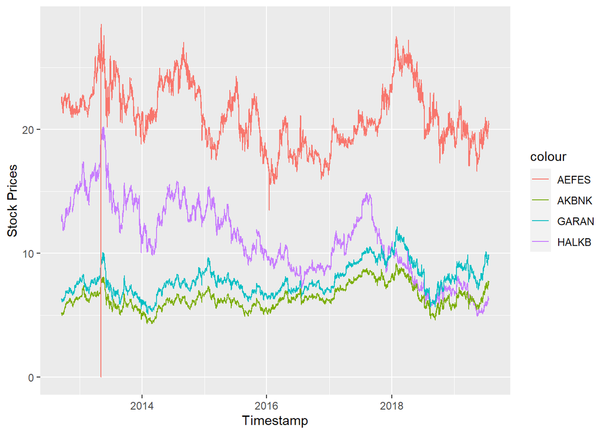

```r
ggplot(data = data) + geom_line(aes(x=timestamp,y=HALKB,group=1,color="HALKB"))+ geom_line(aes(x=timestamp,y=GARAN,group=2,color="GARAN" ))+ geom_line(aes(x=timestamp,y=AKBNK,group=2,color="AKBNK" ))+  geom_line(aes(x=timestamp,y=AEFES,group=2,color="AEFES" ))+labs(x = "Timestamp",
         y = "Stock Prices")
```

```r
unt_test=ur.kpss(data$HALKB)
summary(unt_test)
```

```
##
## #######################
## # KPSS Unit Root Test #
## #######################
##
## Test is of type: mu with 18 lags.
##
## Value of test-statistic is: 169.0874
##
## Critical value for a significance level of:
##                 10pct  5pct 2.5pct  1pct
## critical values 0.347 0.463  0.574 0.739
```

```r
unt_test=ur.kpss(data$GARAN)
summary(unt_test)
```

```
##
## #######################
## # KPSS Unit Root Test #
## #######################
##
## Test is of type: mu with 18 lags.
##
## Value of test-statistic is: 76.2204
##
## Critical value for a significance level of:
##                 10pct  5pct 2.5pct  1pct
## critical values 0.347 0.463  0.574 0.739
```

```r
unt_test=ur.kpss(data$AEFES)
summary(unt_test)
```

```
##
## #######################
## # KPSS Unit Root Test #
## #######################
##
## Test is of type: mu with 18 lags.
##
## Value of test-statistic is: 33.0509
##
## Critical value for a significance level of:
##                 10pct  5pct 2.5pct  1pct
## critical values 0.347 0.463  0.574 0.739
```

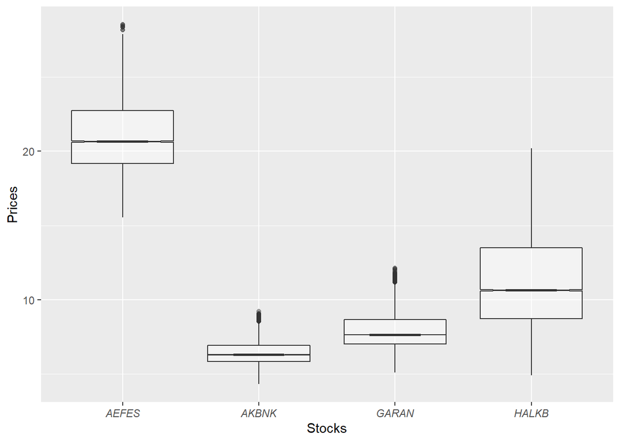

```r
ggplot(data = filter(data_long,short_name == c("HALKB","GARAN","AKBNK","AEFES")), aes(x = short_name, y = price)) +
  geom_boxplot(alpha = 0.4, notch = TRUE) +
  labs(x="Stocks",y = "Prices") +
  theme(axis.text.x = element_text(face = "italic"))
```

```r
test_data <- data[,c("timestamp","HALKB","GARAN")]

test_data <- aggregate(list(GARAN = test_data$GARAN,HALKB=test_data$HALKB),
          list(Day = cut(test_data$timestamp, "1 day")),
          mean, na.action=na.omit)

for (i in 1:length(test_data$Day)){
  if (is.na(test_data$HALKB[i])){
    test_data$HALKB[i] <- test_data$HALKB[i-1]
  }
  if (is.na(test_data$GARAN[i])){
    test_data$GARAN[i] <- test_data$GARAN[i-1]
  }
}
corr_mat = data.table(test_data$Day, cor=0)
for (i in 1:length(test_data$Day)){

 corr_mat$cor[i] =  cor(test_data$HALKB[i:(i+30)], test_data$GARAN[i:(i+30)])

}
```

[output not shown]

[output cut: 25 more lines]

[output not shown]

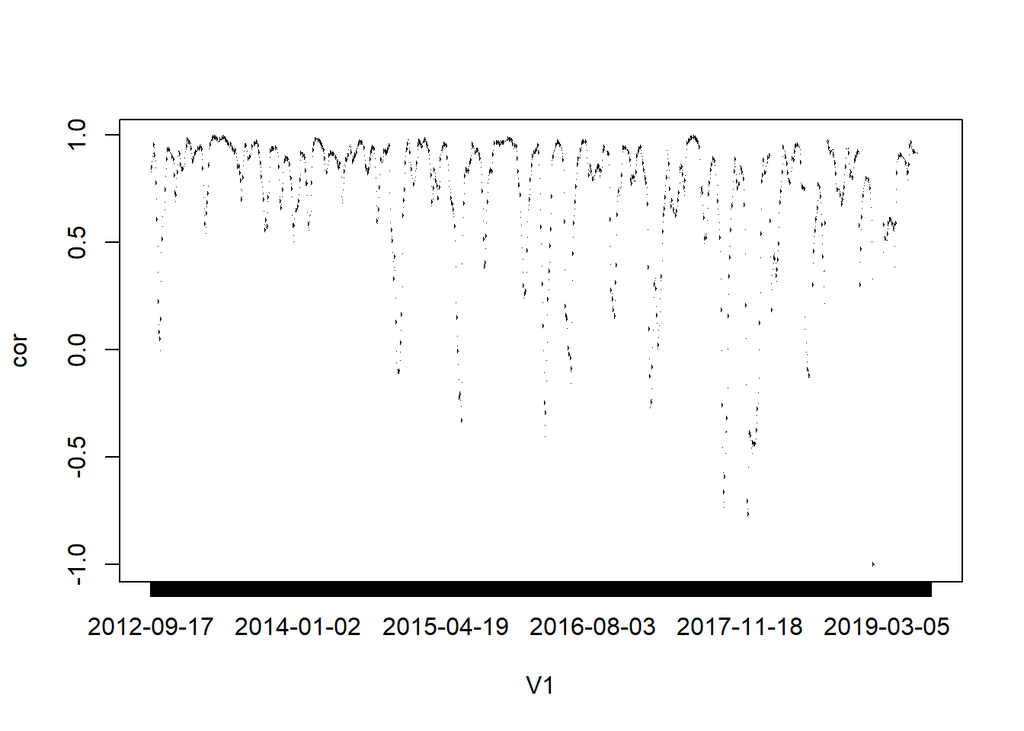

```r
#check HALKB and GARAN

plot(corr_mat, type="l")
```

When principal component analysis is applied to the dataset, it can be seen that first 11 components capture the 95% of the variation among the dataset.

```r
pca_obj = princomp(na.omit(data[,-1]),cor=T, na.rm = TRUE)
summary(pca_obj,loadings=T)
```

```
## Importance of components:
##                           Comp.1    Comp.2    Comp.3     Comp.4     Comp.5
## Standard deviation     4.4239769 3.8883916 3.3072315 1.91257436 1.66717858
## Proportion of Variance 0.3261929 0.2519931 0.1822963 0.06096568 0.04632474
## Cumulative Proportion  0.3261929 0.5781860 0.7604824 0.82144803 0.86777277
##                            Comp.6     Comp.7     Comp.8     Comp.9     Comp.10
## Standard deviation     1.36579977 0.99989145 0.88306889 0.80862554 0.705379875
## Proportion of Variance 0.03109015 0.01666305 0.01299684 0.01089792 0.008292679
## Cumulative Proportion  0.89886292 0.91552597 0.92852281 0.93942073 0.947713414
##                            Comp.11     Comp.12     Comp.13     Comp.14
## Standard deviation     0.634050398 0.583702845 0.533534141 0.475672150
## Proportion of Variance 0.006700332 0.005678484 0.004744311 0.003771067
## Cumulative Proportion  0.954413746 0.960092230 0.964836541 0.968607607
##                           Comp.15     Comp.16     Comp.17     Comp.18
## Standard deviation     0.43232767 0.387851270 0.360380443 0.354355410
## Proportion of Variance 0.00311512 0.002507143 0.002164568 0.002092796
## Cumulative Proportion  0.97172273 0.974229871 0.976394439 0.978487235
##                            Comp.19     Comp.20     Comp.21     Comp.22
## Standard deviation     0.340673277 0.317299565 0.297948139 0.286828997
## Proportion of Variance 0.001934305 0.001677984 0.001479552 0.001371181
## Cumulative Proportion  0.980421540 0.982099523 0.983579075 0.984950256
##                            Comp.23     Comp.24     Comp.25      Comp.26
## Standard deviation     0.280243283 0.262694050 0.249617186 0.2416969251
## Proportion of Variance 0.001308938 0.001150136 0.001038479 0.0009736234
## Cumulative Proportion  0.986259194 0.987409330 0.988447809 0.9894214326
##                             Comp.27      Comp.28      Comp.29      Comp.30
## Standard deviation     0.2285949271 0.2123262991 0.2051813764 0.1982332310
## Proportion of Variance 0.0008709273 0.0007513743 0.0007016566 0.0006549402
## Cumulative Proportion  0.9902923600 0.9910437343 0.9917453909 0.9924003311
##                             Comp.31      Comp.32      Comp.33      Comp.34
## Standard deviation     0.1908398076 0.1853507848 0.1706826757 0.1669624976
## Proportion of Variance 0.0006069972 0.0005725819 0.0004855429 0.0004646079
## Cumulative Proportion  0.9930073283 0.9935799102 0.9940654531 0.9945300611
##                             Comp.35     Comp.36      Comp.37      Comp.38
## Standard deviation     0.1590024279 0.155843187 0.1553781484 0.1460474553
## Proportion of Variance 0.0004213629 0.000404785 0.0004023728 0.0003554977
## Cumulative Proportion  0.9949514239 0.995356209 0.9957585817 0.9961140794
##                             Comp.39      Comp.40      Comp.41      Comp.42
## Standard deviation     0.1403824046 0.1320562490 0.1287146393 0.1265162697
## Proportion of Variance 0.0003284537 0.0002906475 0.0002761243 0.0002667728
```

[output cut: 435 more lines]

```
## THYAO          0.302           0.115
## TKFEN  0.187  -0.253
## TOASO                  0.107
## TRKCM  0.104   0.116           0.113
## TSKB          -0.182
## TTKOM  0.131           0.120
## TUKAS          0.127   0.214   0.325
## TUPRS -0.249   0.147  -0.132
## USAK  -0.208  -0.149
## VAKBN -0.341          -0.403   0.435   0.157
## VESTL -0.159
## YATAS         -0.159   0.108
## YKBNK -0.140   0.596   0.103  -0.285
## YUNSA                          0.111
## ZOREN
```

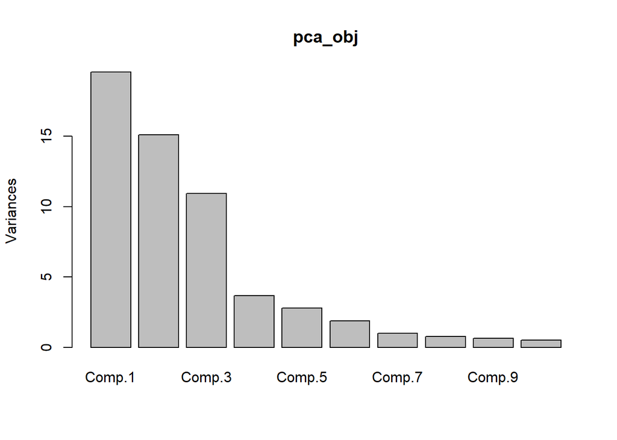

```r
plot(pca_obj)
```